# Investigating The European Soccer Database

- Introduction
- Data Wrangling
- Exploratory Data Analysis
- Conclusions

# Introduction:

### The European Soccer Database

#### 25k+ matches, players & teams attributes for European Professional Football

The ultimate Soccer database for data analysis and machine learning! It contains data for soccer matches, players, and teams from several European countries from 2008 to 2016.

#### The database includes:

+25,000 matches +10,000 players 11 European Countries with their lead championship Seasons 2008 to 2016 Players and Teams' attributes* sourced from EA Sports' FIFA video game series, including the weekly updates This soccer database comes from Kaggle and is well suited for data analysis and machine learning.

● The database is stored in a SQLite database, and I accessed its files using the 'DB Browser(SQLite)' software.

● The dataset helped me practice my SQL joins skills.

● Some column titles was self-explanatory, while others I had to look up them on Kaggle.

```python
# Import statements for all of the packages that I will use.
import pandas as pd
from sqlalchemy import create_engine
from sqlalchemy import inspect
import numpy as np
from datetime import datetime
import matplotlib.pyplot as plt
import seaborn as sns

# The 'magic word' so that the visualizations are plotted inline with the notebook.
%matplotlib inline
```

## Data Wrangling

> In this section, I load in the data, check for cleanliness, and then trim and clean the dataset for analysis. The steps are documented carefully and the cleaning decisions are justified.

```python
# create an engine to connect to the database
db_url = 'sqlite:///database.sqlite'
engine = create_engine(db_url)
```

```python
# inspect the database for the Tables names and their count
inspector = inspect(engine)
print('The database has {} tables:'.format(len(inspector.get_table_names())))
print(inspector.get_table_names())
```

```
The database has 8 tables:
['Country', 'League', 'Match', 'Player', 'Player_Attributes', 'Team', 'Team_Attributes', 'sqlite_sequence']
```

#### I will export from the database two data sets to invistigate:

```
1. Data set of the teams attributes
2. Data set of the players attributes
```

### First Data Set: Teams Attributes Data Set

```python
# Run a query to acquire 3 team attributes along with the teams names and dates of their attributes scores
stmt = """ SELECT DISTINCT Team_Attributes.date, Team.team_short_name, Team.team_long_name, Team_Attributes.buildUpPlaySpeed,
                  Team_Attributes.buildUpPlayDribbling,
                  Team_Attributes.buildUpPlayPassing
           FROM Team
           JOIN Team_Attributes ON Team.team_api_id = Team_Attributes.team_api_id"""
df_teams = pd.read_sql(stmt, engine)
df_teams.info()
df_teams.head()
```

```
<class 'pandas.core.frame.DataFrame'>
RangeIndex: 1457 entries, 0 to 1456
Data columns (total 6 columns):
 #   Column                Non-Null Count  Dtype
---  ------                --------------  -----
 0   date                  1457 non-null   object
 1   team_short_name       1457 non-null   object
 2   team_long_name        1457 non-null   object
 3   buildUpPlaySpeed      1457 non-null   int64
 4   buildUpPlayDribbling  488 non-null    float64
 5   buildUpPlayPassing    1457 non-null   int64
dtypes: float64(1), int64(2), object(3)
memory usage: 68.4+ KB
```

|  | date | team_short_name | team_long_name | buildUpPlaySpeed | buildUpPlayDribbling | buildUpPlayPassing |
| --- | --- | --- | --- | --- | --- | --- |
| 0 | 2010-02-22 00:00:00 | AAR | FC Aarau | 60 | NaN | 50 |
| 1 | 2014-09-19 00:00:00 | AAR | FC Aarau | 52 | 48.0 | 56 |
| 2 | 2015-09-10 00:00:00 | AAR | FC Aarau | 47 | 41.0 | 54 |
| 3 | 2010-02-22 00:00:00 | ABE | Aberdeen | 70 | NaN | 70 |
| 4 | 2011-02-22 00:00:00 | ABE | Aberdeen | 47 | NaN | 52 |

### Second Data Set: Players Attributes Data Set

```python
# Acquire the second data set from the database.
stmt = """ SELECT DISTINCT Player_Attributes.date, Player.player_name, Player.birthday, Player.height, player.weight,
           Player_Attributes.overall_rating, Player_Attributes.penalties, Player_Attributes.preferred_foot,
           Player_Attributes.heading_accuracy, Player_Attributes.free_kick_accuracy, Player_Attributes.shot_power,
           Player_Attributes.strength, Player_Attributes.potential, Player_Attributes.attacking_work_rate,
           Player_Attributes.defensive_work_rate, Player_Attributes.ball_control,  Player_Attributes.acceleration,
           Player_Attributes.finishing
           FROM Player
           JOIN Player_Attributes ON Player.player_api_id = Player_Attributes.player_api_id"""
df_players = pd.read_sql(stmt, engine)
df_players.info()
df_players.head(5)
```

```
<class 'pandas.core.frame.DataFrame'>
RangeIndex: 183977 entries, 0 to 183976
Data columns (total 18 columns):
 #   Column               Non-Null Count   Dtype
---  ------               --------------   -----
 0   date                 183977 non-null  object
 1   player_name          183977 non-null  object
 2   birthday             183977 non-null  object
 3   height               183977 non-null  float64
 4   weight               183977 non-null  int64
 5   overall_rating       183142 non-null  float64
 6   penalties            183142 non-null  float64
 7   preferred_foot       183142 non-null  object
 8   heading_accuracy     183142 non-null  float64
 9   free_kick_accuracy   183142 non-null  float64
 10  shot_power           183142 non-null  float64
 11  strength             183142 non-null  float64
 12  potential            183142 non-null  float64
 13  attacking_work_rate  180748 non-null  object
 14  defensive_work_rate  183142 non-null  object
 15  ball_control         183142 non-null  float64
 16  acceleration         183142 non-null  float64
 17  finishing            183142 non-null  float64
dtypes: float64(11), int64(1), object(6)
memory usage: 25.3+ MB
```

|  | date | player_name | birthday | height | weight | overall_rating | penalties | preferred_foot | heading_accuracy | free_kick_accuracy | shot_power | strength | potential | attacking_work_rate | defensive_work_rate | ball_control | acceleration | finishing |
| --- | --- | --- | --- | --- | --- | --- | --- | --- | --- | --- | --- | --- | --- | --- | --- | --- | --- | --- |
| 0 | 2016-02-18 00:00:00 | Aaron Appindangoye | 1992-02-29 00:00:00 | 182.88 | 187 | 67.0 | 48.0 | right | 71.0 | 39.0 | 55.0 | 76.0 | 71.0 | medium | medium | 49.0 | 60.0 | 44.0 |
| 1 | 2015-11-19 00:00:00 | Aaron Appindangoye | 1992-02-29 00:00:00 | 182.88 | 187 | 67.0 | 48.0 | right | 71.0 | 39.0 | 55.0 | 76.0 | 71.0 | medium | medium | 49.0 | 60.0 | 44.0 |
| 2 | 2015-09-21 00:00:00 | Aaron Appindangoye | 1992-02-29 00:00:00 | 182.88 | 187 | 62.0 | 48.0 | right | 71.0 | 39.0 | 55.0 | 76.0 | 66.0 | medium | medium | 49.0 | 60.0 | 44.0 |
| 3 | 2015-03-20 00:00:00 | Aaron Appindangoye | 1992-02-29 00:00:00 | 182.88 | 187 | 61.0 | 47.0 | right | 70.0 | 38.0 | 54.0 | 76.0 | 65.0 | medium | medium | 48.0 | 60.0 | 43.0 |
| 4 | 2007-02-22 00:00:00 | Aaron Appindangoye | 1992-02-29 00:00:00 | 182.88 | 187 | 61.0 | 47.0 | right | 70.0 | 38.0 | 54.0 | 76.0 | 65.0 | medium | medium | 48.0 | 60.0 | 43.0 |

### We notice that there are two issues in the Teams Attributes data set:

```
a. NaN values in the 'buildUpPlayDribbling' column
b. Wrong data type of the 'date' column
```

### We notice also the following issues in the Player Attributes data set:

```
a. NaN values in the following columns:
    1- overall_rating
    2- penalties
    3- preferred_foot
    4- heading_accuracy
    5- free_kick_accuracy
    6- shot_power
    7- strength
    8- potential
    9- attacking_work_rate
    10- defensive_work_rate
    11- ball_control
    12- acceleration
    13- finishing

b. Wrong data type of the 'date' and 'birthday' columns
```

> Please notice that the weight column values are in Pounds, not Kilograms

### Data Cleaning

#### 1. Replacing the NaN values

```python
# First data set: Teams Attributes

# Fill NaN Values with the mean of the 'buildUpPlayDribbling' column
df_teams['buildUpPlayDribbling'].fillna(df_teams['buildUpPlayDribbling'].mean(), inplace = True)

# Limit new float values in the 'buildUpPlayDribbling' column to two numbers after the decimal point
df_teams['buildUpPlayDribbling'] = df_teams['buildUpPlayDribbling'].round(2)
```

```python
# Second data set: Players Attributes

# 1. Fill NaN Values with the mean of the 'overall_rating' column
df_players['overall_rating'].fillna(df_players['overall_rating'].mean(), inplace = True)

# 2. Fill NaN Values with the mean of the 'penalties' column
df_players['penalties'].fillna(df_players['penalties'].mean(), inplace = True)

# 3. Fill NaN Values with the mode of the 'preferred_foot' column
df_players['preferred_foot'].fillna(df_players['preferred_foot'].mode()[0], inplace = True)

# 4. Fill NaN Values with the mean of the 'heading_accuracy' column
df_players['heading_accuracy'].fillna(df_players['heading_accuracy'].mean(), inplace = True)

# 5. Fill NaN Values with the mean of the 'free_kick_accuracy' column
df_players['free_kick_accuracy'].fillna(df_players['free_kick_accuracy'].mean(), inplace = True)

# 6. Fill NaN Values with the mean of the 'shot_power' column
df_players['shot_power'].fillna(df_players['shot_power'].mean(), inplace = True)

# 7. Fill NaN Values with the mean of the 'strength' column
df_players['strength'].fillna(df_players['strength'].mean(), inplace = True)

# 8. Fill NaN Values with the mean of the 'potential' column
df_players['potential'].fillna(df_players['potential'].mean(), inplace = True)

# 9. Fill NaN Values with the mode of the 'attacking_work_rate' column
df_players['attacking_work_rate'].fillna(df_players['attacking_work_rate'].mode()[0], inplace = True)

# 10. Fill NaN Values with the mean of the 'defensive_work_rate' column
df_players['defensive_work_rate'].fillna(df_players['defensive_work_rate'].mode()[0], inplace = True)

# 11. Fill NaN Values with the mean of the 'ball_control' column
df_players['ball_control'].fillna(df_players['ball_control'].mean(), inplace = True)

# 12. Fill NaN Values with the mean of the 'acceleration' column
df_players['acceleration'].fillna(df_players['acceleration'].mean(), inplace = True)

# 13. Fill NaN Values with the mean of the 'finishing' column
df_players['finishing'].fillna(df_players['finishing'].mean(), inplace = True)
```

#### 2. Fix the wrong data type

```python
# First data set: Teams Attributes

# Fix the data tpye of the 'date' column
df_teams['date'] = pd.to_datetime(df_teams['date'])
```

```python
# Second data set: Player Attributes

# Fix the data tpye of the 'date' column
df_players['date'] = pd.to_datetime(df_players['date'])

# Fix the data tpye of the 'date' column
df_players['birthday'] = pd.to_datetime(df_players['birthday'])
```

```python
# Inspect the Teams Attributes data set after the data cleaning
df_teams.info()
df_teams.head()
```

```
<class 'pandas.core.frame.DataFrame'>
RangeIndex: 1457 entries, 0 to 1456
Data columns (total 6 columns):
 #   Column                Non-Null Count  Dtype
---  ------                --------------  -----
 0   date                  1457 non-null   datetime64[ns]
 1   team_short_name       1457 non-null   object
 2   team_long_name        1457 non-null   object
 3   buildUpPlaySpeed      1457 non-null   int64
 4   buildUpPlayDribbling  1457 non-null   float64
 5   buildUpPlayPassing    1457 non-null   int64
dtypes: datetime64[ns](1), float64(1), int64(2), object(2)
memory usage: 68.4+ KB
```

|  | date | team_short_name | team_long_name | buildUpPlaySpeed | buildUpPlayDribbling | buildUpPlayPassing |
| --- | --- | --- | --- | --- | --- | --- |
| 0 | 2010-02-22 | AAR | FC Aarau | 60 | 48.6 | 50 |
| 1 | 2014-09-19 | AAR | FC Aarau | 52 | 48.0 | 56 |
| 2 | 2015-09-10 | AAR | FC Aarau | 47 | 41.0 | 54 |
| 3 | 2010-02-22 | ABE | Aberdeen | 70 | 48.6 | 70 |
| 4 | 2011-02-22 | ABE | Aberdeen | 47 | 48.6 | 52 |

```python
# Inspect the Players Attributes data set after the data cleaning
df_players.info()
df_players.head()
```

```
<class 'pandas.core.frame.DataFrame'>
RangeIndex: 183977 entries, 0 to 183976
Data columns (total 18 columns):
 #   Column               Non-Null Count   Dtype
---  ------               --------------   -----
 0   date                 183977 non-null  datetime64[ns]
 1   player_name          183977 non-null  object
 2   birthday             183977 non-null  datetime64[ns]
 3   height               183977 non-null  float64
 4   weight               183977 non-null  int64
 5   overall_rating       183977 non-null  float64
 6   penalties            183977 non-null  float64
 7   preferred_foot       183977 non-null  object
 8   heading_accuracy     183977 non-null  float64
 9   free_kick_accuracy   183977 non-null  float64
 10  shot_power           183977 non-null  float64
 11  strength             183977 non-null  float64
 12  potential            183977 non-null  float64
 13  attacking_work_rate  183977 non-null  object
 14  defensive_work_rate  183977 non-null  object
 15  ball_control         183977 non-null  float64
 16  acceleration         183977 non-null  float64
 17  finishing            183977 non-null  float64
dtypes: datetime64[ns](2), float64(11), int64(1), object(4)
memory usage: 25.3+ MB
```

|  | date | player_name | birthday | height | weight | overall_rating | penalties | preferred_foot | heading_accuracy | free_kick_accuracy | shot_power | strength | potential | attacking_work_rate | defensive_work_rate | ball_control | acceleration | finishing |
| --- | --- | --- | --- | --- | --- | --- | --- | --- | --- | --- | --- | --- | --- | --- | --- | --- | --- | --- |
| 0 | 2016-02-18 | Aaron Appindangoye | 1992-02-29 | 182.88 | 187 | 67.0 | 48.0 | right | 71.0 | 39.0 | 55.0 | 76.0 | 71.0 | medium | medium | 49.0 | 60.0 | 44.0 |
| 1 | 2015-11-19 | Aaron Appindangoye | 1992-02-29 | 182.88 | 187 | 67.0 | 48.0 | right | 71.0 | 39.0 | 55.0 | 76.0 | 71.0 | medium | medium | 49.0 | 60.0 | 44.0 |
| 2 | 2015-09-21 | Aaron Appindangoye | 1992-02-29 | 182.88 | 187 | 62.0 | 48.0 | right | 71.0 | 39.0 | 55.0 | 76.0 | 66.0 | medium | medium | 49.0 | 60.0 | 44.0 |
| 3 | 2015-03-20 | Aaron Appindangoye | 1992-02-29 | 182.88 | 187 | 61.0 | 47.0 | right | 70.0 | 38.0 | 54.0 | 76.0 | 65.0 | medium | medium | 48.0 | 60.0 | 43.0 |
| 4 | 2007-02-22 | Aaron Appindangoye | 1992-02-29 | 182.88 | 187 | 61.0 | 47.0 | right | 70.0 | 38.0 | 54.0 | 76.0 | 65.0 | medium | medium | 48.0 | 60.0 | 43.0 |

### Now that we have successfully trimmed and cleaned our data sets, we're ready to move on to exploration!

## Exploratory Data Analysis

> In this section we will Compute statistics and create visualizations with the goal of addressing the research questions that we've posed in the Introduction section. I used a systematic pproach where I Looked at one variable at a time, and then followed it up by looking at relationships between it and the other variables.

### Research Question 1: What teams improved the most over the time period?

```
Top 5 Teams in Terms of Building up Player Dribbling:
1. Borussia Dortmund
2. Udinese
3. Falkirk
4. FC Arouca
5. Bayer 04 Leverkusen
```

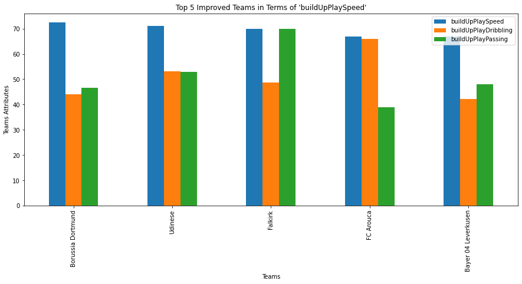

```python
# Getting the top 5 improved teams in terms of 'buildUpPlaySpeed' over the time
top_play_speed = []
play_speed = df_teams.groupby('team_long_name').mean().sort_values(['buildUpPlaySpeed'], ascending = False).round(2).head(5)
play_speed.plot(kind = 'bar', figsize = (15, 6));
plt.title("Top 5 Improved Teams in Terms of 'buildUpPlaySpeed'")
plt.xlabel('Teams')
plt.ylabel('Teams Attributes');
print("Top 5 Teams in Terms of Building up Player Dribbling: ")
i = 1
for team in play_speed.index:
    print('{}.'.format(i), team)
    top_play_speed.append(team)
    i += 1
```

```
Top 5 Teams in Terms of Building up Player Dribbling:
1. FC Arouca
2. Gil Vicente FC
3. Napoli
4. Boavista FC
5. Milan
```

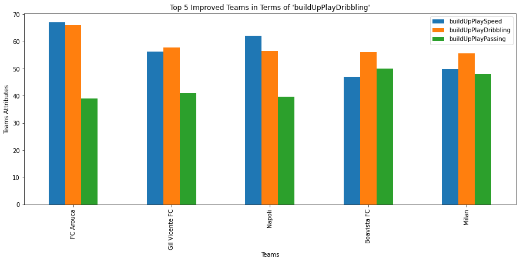

```python
# Getting the top 5 improved teams in terms of teams 'buildUpPlayDribbling' over the time period
play_dribbling = df_teams.groupby('team_long_name').mean().sort_values(['buildUpPlayDribbling'], ascending = False).round(2).head(5)
play_dribbling.plot(kind = 'bar', figsize = (15, 6));
plt.title("Top 5 Improved Teams in Terms of 'buildUpPlayDribbling'")
plt.xlabel('Teams')
plt.ylabel('Teams Attributes');
top_play_dribbling = []
print("Top 5 Teams in Terms of Building up Player Dribbling: ")
i = 1
for team in play_dribbling.index:
    print('{}.'.format(i), team)
    top_play_dribbling.append(team)
    i += 1
```

```
1. SV Darmstadt 98
2. Falkirk
3. Stoke City
4. Birmingham City
5. Bolton Wanderers
```

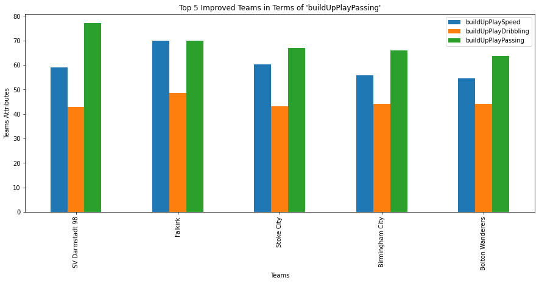

```python
# Getting the top 5 improved teams in terms of teams 'buildUpPlayPassing' over the time period
play_Passing = df_teams.groupby('team_long_name').mean().sort_values(['buildUpPlayPassing'], ascending = False).round(2).head(5)
play_Passing.plot(kind = 'bar', figsize = (15, 6));
plt.title("Top 5 Improved Teams in Terms of 'buildUpPlayPassing'")
plt.xlabel('Teams')
plt.ylabel('Teams Attributes');
top_play_Passing = []
i = 1
for team in play_Passing.index:
    print('{}.'.format(i), team)
    top_play_Passing.append(team)
    i += 1
```

```python
# Getting the teams that improved the most over the time in more than one attribute of the 3 attributes we've investigated!
print(top_play_speed)
print(top_play_dribbling)
print(top_play_Passing)
intersection_1 = list(set(top_play_speed).intersection(top_play_dribbling))
intersection_2 = list(set(top_play_speed).intersection(top_play_Passing))
intersection_3 = list(set(top_play_dribbling).intersection(top_play_Passing))
print(intersection_1)
print(intersection_2)
print(intersection_3)
```

```
['Borussia Dortmund', 'Udinese', 'Falkirk', 'FC Arouca', 'Bayer 04 Leverkusen']
['FC Arouca', 'Gil Vicente FC', 'Napoli', 'Boavista FC', 'Milan']
['SV Darmstadt 98', 'Falkirk', 'Stoke City', 'Birmingham City', 'Bolton Wanderers']
['FC Arouca']
['Falkirk']
[]
```

### Conclusion:

#### 'FC Arouca' team improved the most over the time in terms of:

```
1. buildUpPlaySpeed
2. buildUpPlayDribbling
```

#### 'Falkirk' team improved the most overtime in terms of:

```
1. buildUpPlaySpeed
2. buildUpPlayPassing
```

Let's raise a question here: Since 'FC Arouca' team has imporved in both 'buildUpPlaySpeed' and 'buildUpPlayDribbling',

### is there a relationship between 'buildUpPlaySpeed' and 'buildUpPlayDribbling' attributes? Let's Find out!

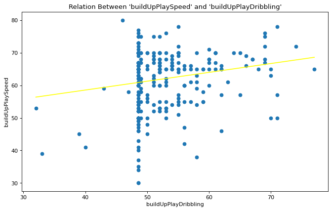

```python
# Draw a scatter graph between 'buildUpPlaySpeed' and 'buildUpPlayDribbling' attributes
df = df_teams[['team_long_name', 'buildUpPlaySpeed', 'buildUpPlayDribbling']].groupby('team_long_name').max()
x = df['buildUpPlayDribbling'].values
y = df['buildUpPlaySpeed'].values
plt.figure(figsize=(10, 6), dpi=80)
plt.scatter(x, y)
plt.plot(np.unique(x), np.poly1d(np.polyfit(x, y, 1))(np.unique(x)), color='yellow');
plt.title("Relation Between 'buildUpPlaySpeed' and 'buildUpPlayDribbling'")
plt.xlabel('buildUpPlayDribbling')
plt.ylabel('buildUpPlaySpeed');
```

### Conclusion:

It appears that there is a low positive correlation between the 'buildUpPlaySpeed' and 'buildUpPlayDribbling' attributes. This suggests that the teams which improve in 'buildUpPlaySpeed' may improve as well in 'buildUpPlayDribbling.

#### Let's raise another question:

since 'Falkirk' team has imporved in both 'buildUpPlaySpeed' and 'buildUpPlayPassing',

### is there a relationship between 'buildUpPlaySpeed' and 'buildUpPlayPassing' attributes?!

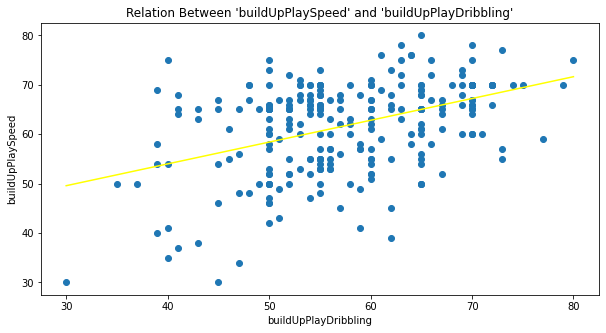

```python
# Draw a scatter graph between 'buildUpPlaySpeed' and ''buildUpPlayPassing' attributes
df = df_teams[['team_long_name', 'buildUpPlaySpeed', 'buildUpPlayPassing']].groupby('team_long_name').max()
x = df['buildUpPlayPassing'].values
y = df['buildUpPlaySpeed'].values
plt.figure(figsize=(10, 5))
plt.scatter(x, y)
plt.plot(np.unique(x), np.poly1d(np.polyfit(x, y, 1))(np.unique(x)), color='yellow');
plt.title("Relation Between 'buildUpPlaySpeed' and 'buildUpPlayDribbling'")
plt.xlabel('buildUpPlayDribbling')
plt.ylabel('buildUpPlaySpeed');
```

### Conclusion:

Final question I will raise regarding this point: since we didn't encounter a team that improved in both 'buildUpPlayPassing' and 'buildUpPlayDribbling' attributes,

### is there a relationship between 'buildUpPlayPassing' and 'buildUpPlayDribbling' attributes?!

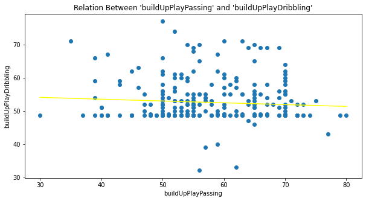

```python
# Draw a scatter graph between 'buildUpPlayPassing' and ''buildUpPlayDribbling' attributes
df = df_teams[['team_long_name', 'buildUpPlayPassing', 'buildUpPlayDribbling']].groupby('team_long_name').max()
x = df['buildUpPlayPassing'].values
y = df['buildUpPlayDribbling'].values
plt.figure(figsize=(10, 5))
plt.scatter(x, y)
plt.plot(np.unique(x), np.poly1d(np.polyfit(x, y, 1))(np.unique(x)), color='yellow');
plt.title("Relation Between 'buildUpPlayPassing' and 'buildUpPlayDribbling'")
plt.xlabel('buildUpPlayPassing')
plt.ylabel('buildUpPlayDribbling');
```

### Conclusion:

There seems to be a small negative correlation between the 'buildUpPlayPassing' and 'buildUpPlayDribbling' attributes. This suggests a possibility that if a team improved in one attribute may not improve in another.

### Research Question 2: Which players had the most penalties?

```python
df = df_players[['player_name', 'penalties']].groupby('player_name').max()
df = df.sort_values(['penalties'], ascending = False).head(5)
df
```

| player_name | penalties |
| --- | --- |
| Rickie Lambert | 96.0 |
| Paul Scholes | 95.0 |
| Xavi Hernandez | 95.0 |
| Mario Balotelli | 95.0 |
| Andrea Pirlo | 95.0 |

### Conclusion:

#### Top 5 Players Who Had The Most Penalties:

[output not shown]

### Research Question 3: Statistics of Players' Age

```
The Youngest Player = 54
The Oldest Player = 22
The Mean Player Age = 34
The Mode Player Age = 33
```

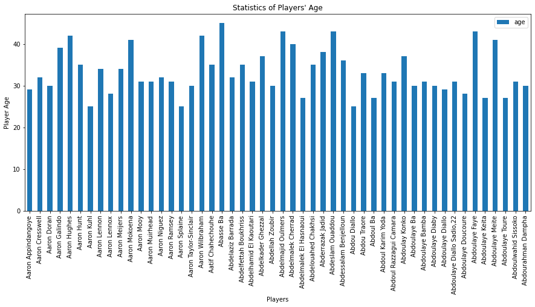

```python
# Find some of the descriptive statistics about the players' Age, and plot the 50 samples of the players' age.
current_year = datetime.now().year
df_players['age'] = current_year - df_players['birthday'].dt.year
max_age = df_players['age'].min()
min_age = df_players['age'].max()
mean_age = df_players['age'].mean()
mode_age = df_players['age'].mode()[0]

print('The Youngest Player = {}'.format(min_age))
print('The Oldest Player = {}'.format(max_age))
print('The Mean Player Age = {}'.format(int(mean_age)))
print('The Mode Player Age = {}'.format(int(mode_age)))

player_height = df_players[['player_name', 'age']].groupby('player_name').mean().head(50)
player_height.plot(kind = 'bar', figsize = (15, 6));
plt.title("Statistics of Players' Age")
plt.xlabel('Players')
plt.ylabel('Player Age');
```

### Does The Age of a Player Affect His Overall Rating?

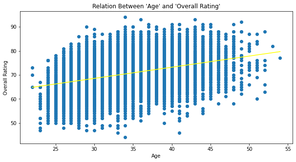

```python
# Plot the 'age' column against the 'overall_rating' column
df = df_players[['player_name', 'age', 'overall_rating']].groupby('player_name').max().head(10000)
#df.plot(x= 'birth_year', y = 'overall_rating', kind = 'scatter' );
x = df['age'].values
y = df['overall_rating'].values
plt.figure(figsize=(10, 5))
plt.scatter(x, y)
plt.plot(np.unique(x), np.poly1d(np.polyfit(x, y, 1))(np.unique(x)), color='yellow');
plt.title("Relation Between 'Age' and 'Overall Rating'")
plt.xlabel('Age')
plt.ylabel('Overall Rating');
```

### Conclusion:

There is a moderate positive correlation between the age and the overall rating, which suggests that the older the player is, the higher the overall rating he is likely to have.

### Research Question 4: Statistics of Players' Heights

```
Minimum Player Height = 157
Maximum Player Height = 208
Mean Player Height = 181
Mode Player Height = 182
```

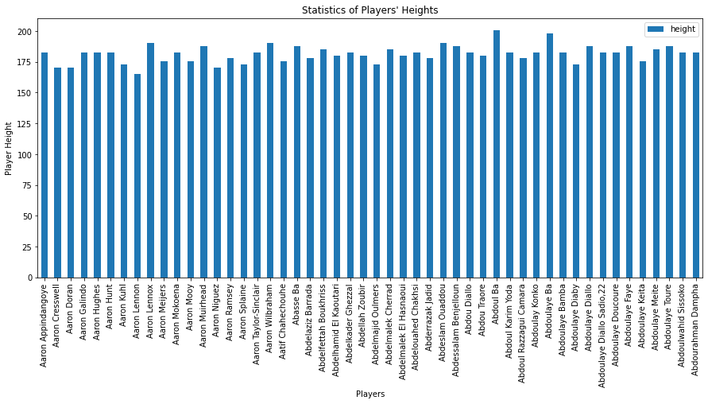

```python
# Find some of the descriptive statistics about the players' heights, and plot the 50 samples of the height variable.
min_height = df_players['height'].min()
max_height = df_players['height'].max()
mean_height = df_players['height'].mean()
mode_height = df_players['height'].mode()

player_height = df_players[['player_name', 'height']].groupby('player_name').mean().head(50)
player_height.plot(kind = 'bar', figsize = (15, 6));
plt.title("Statistics of Players' Heights")
plt.xlabel('Players')
plt.ylabel('Player Height');

print('Minimum Player Height = {}'.format(int(min_height)))
print('Maximum Player Height = {}'.format(int(max_height)))
print('Mean Player Height = {}'.format(int(mean_height)))
print('Mode Player Height = {}'.format(int(mode_height)))
```

### Conclusion:

**Statistics of Players' Heights:**  
Minimum Player Height = 157  
Maximum Player Height = 208  
Mean Player Height = 181  
Mode Player Height = 182

### Does The height of a player Affect his Acceleration?

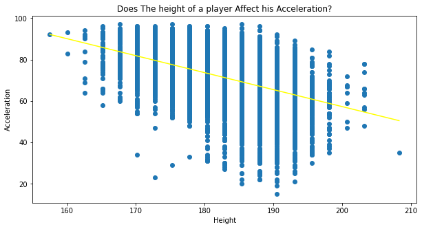

```python
# Plot the 'height' column against the 'acceleration' column
df = df_players[['player_name', 'height', 'acceleration']].groupby('player_name').max().head(10000)
#df.plot(x= 'height', y = 'acceleration', kind = 'scatter' );
x = df['height'].values
y = df['acceleration'].values
plt.figure(figsize=(10, 5))
plt.scatter(x, y)
plt.plot(np.unique(x), np.poly1d(np.polyfit(x, y, 1))(np.unique(x)), color='yellow');
plt.title("Does The height of a player Affect his Acceleration?")
plt.xlabel('Height')
plt.ylabel('Acceleration');
```

### Does The height of a player Affect his Heading Accuracy?

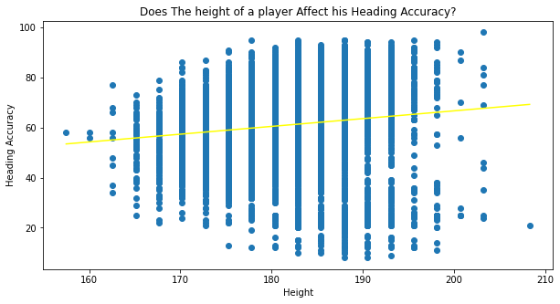

```python
# Plot the 'height' column against the 'heading_accuracy' column
df = df_players[['player_name', 'height', 'heading_accuracy']].groupby('player_name').max().head(10000)
#df.plot(x= 'height', y = 'acceleration', kind = 'scatter' );
x = df['height'].values
y = df['heading_accuracy'].values
plt.figure(figsize=(10, 5))
plt.scatter(x, y)
plt.plot(np.unique(x), np.poly1d(np.polyfit(x, y, 1))(np.unique(x)), color='yellow');
plt.title("Does The height of a player Affect his Heading Accuracy?")
plt.xlabel('Height')
plt.ylabel('Heading Accuracy');
```

### Conclusion:

There is a low to moderate positive correlation between the height and the Heading Accuracy of a player, which suggests that the taller the player is, the more Heading Accuracy he has.

## Research Question 5: Statistics of Players' Weight in Pounds

```
Maximum Weight of a Player = 243 Pounds
Minimum Weight of a Player = 117 Pounds
Mean Weight of a Player = 168 Pounds
Mode Weight of a Player = 165 Pounds
```

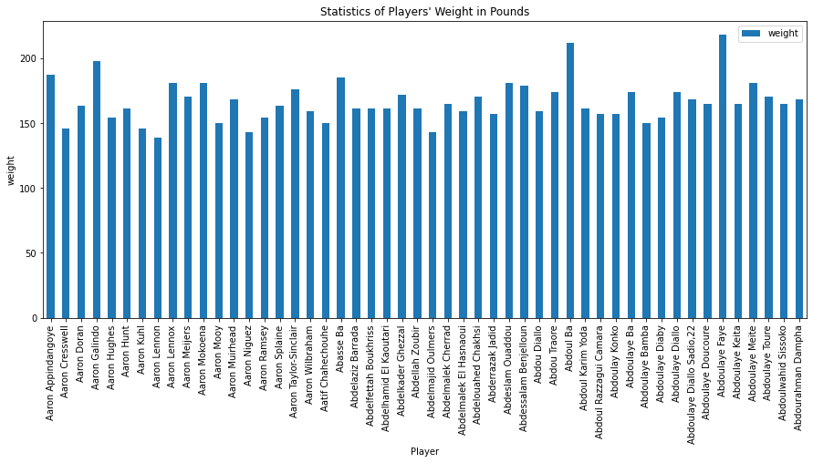

```python
# Find some of the descriptive statistics about the players' weight, and plot the 50 samples of the weight variable.
min_weight = df_players['weight'].min()
max_weight = df_players['weight'].max()
mean_weight = df_players['weight'].mean()
mode_weight = df_players['weight'].mode()[0]

print('Maximum Weight of a Player = {} Pounds'.format(max_weight))
print('Minimum Weight of a Player = {} Pounds'.format(min_weight))
print('Mean Weight of a Player = {} Pounds'.format(int(mean_weight)))
print('Mode Weight of a Player = {} Pounds'.format(mode_weight))

player_height = df_players[['player_name', 'weight']].groupby('player_name').mean().head(50)
player_height.plot(kind = 'bar', figsize = (15, 6));
plt.title("Statistics of Players' Weight in Pounds")
plt.xlabel('Player')
plt.ylabel('weight');
```

### Conclusion:

**Statistics of Players' Weight in Pounds:**  
Maximum Weight of a Player = 243 Pounds  
Minimum Weight of a Player = 117 Pounds  
Mean Weight of a Player = 168.77616767313305 Pounds  
Mode Weight of a Player = 165 Pounds

### Does The weight of a player Affect his Shot Power?

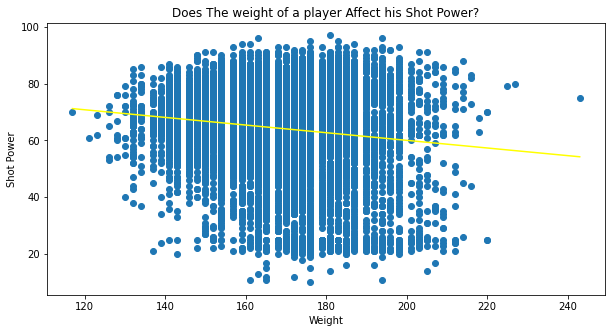

```python
# Plot the 'weight' column against the 'shot_power' column
df = df_players[['player_name', 'weight', 'shot_power']].groupby('player_name').max().head(10000)
#df.plot(x= 'height', y = 'acceleration', kind = 'scatter' );
x = df['weight'].values
y = df['shot_power'].values
plt.figure(figsize=(10, 5))
plt.scatter(x, y)
plt.plot(np.unique(x), np.poly1d(np.polyfit(x, y, 1))(np.unique(x)), color='yellow');
plt.title("Does The weight of a player Affect his Shot Power?")
plt.xlabel('Weight')
plt.ylabel('Shot Power');
```

### Conclusion:

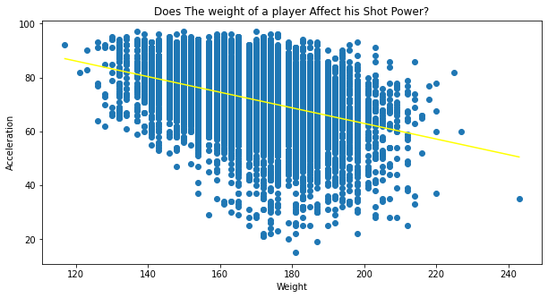

```python
# Plot the 'weight' column against the 'acceleration' column
df = df_players[['player_name', 'weight', 'acceleration']].groupby('player_name').max().head(10000)
#df.plot(x= 'height', y = 'acceleration', kind = 'scatter' );
x = df['weight'].values
y = df['acceleration'].values
plt.figure(figsize=(10, 5))
plt.scatter(x, y)
plt.plot(np.unique(x), np.poly1d(np.polyfit(x, y, 1))(np.unique(x)), color='yellow');
plt.title("Does The weight of a player Affect his Shot Power?")
plt.xlabel('Weight')
plt.ylabel('Acceleration');
```

## Limitations:

- Finding the matches results of each team was hard to find in the 'League' and 'Match' tables in the database, which prevented me from investigating them.

# Final Conclusions:

● 'FC Arouca' team improved the most over the time in terms of:  
$\;\;\;\;\;\;$1. buildUpPlaySpeed  
$\;\;\;\;\;\;$2. buildUpPlayDribbling

● 'Falkirk' team improved the most over the time in terms of:  
$\;\;\;\;\;\;$1. buildUpPlaySpeed  
$\;\;\;\;\;\;$2. buildUpPlayPassing

● It appears that there is a low positive correlation between the 'buildUpPlaySpeed' and 'buildUpPlayDribbling' attributes. This suggests that the teams which improve in 'buildUpPlaySpeed' may improve as well in 'buildUpPlayDribbling.

● There seems to be a small negative correlation between the 'buildUpPlayPassing' and 'buildUpPlayDribbling' attributes. This suggests a possibility that if a team improved in one attribute may not improve in another.

● There is a moderate positive correlation between the age and the overall rating, which suggests that the older the player is, the higher the overall rating he is likely to have.

● Statistics of Players' Heights:  
$\;\;\;\;\;\;$1. Minimum Player Height = 157  
$\;\;\;\;\;\;$2. Maximum Player Height = 208  
$\;\;\;\;\;\;$3. Mean Player Height = 181  
$\;\;\;\;\;\;$4. Mode Player Height = 182

● There is a low to moderate positive correlation between the height and the Heading Accuracy of a player, which suggests that the taller the player is, the more Heading Accuracy he has.

● Statistics of Players' Weight in Pounds:  
$\;\;\;\;\;\;$1. Maximum Weight of a Player = 243 Pounds  
$\;\;\;\;\;\;$2. Minimum Weight of a Player = 117 Pounds  
$\;\;\;\;\;\;$3. Mean Weight of a Player = 168 Pounds  
$\;\;\;\;\;\;$4. Mode Weight of a Player = 165 Pounds